# Homework 1

Xiangyu Ren

#### (1). In class we discussed about both numerical and graphical summaries to describe the data.You will be using the dataset mtcars available in R to make some numerical and graphical summaries. Original data was taken from 1974 Motor Trend US magazine. This dataset include fuel consumption and 10 aspects of automobile design and performance for 32 automobiles (1973–74 models).

##### (a) Use below code lines to access the help file for mtcars dataset and to print the first few observations of the dataset. Your code and the output need to be appear in your answer.

```r
?help(mtcars)
# help(mtcars)
head(mtcars)
```

|  | mpg | cyl | disp | hp | drat | wt | qsec | vs | am | gear | carb |
| --- | --- | --- | --- | --- | --- | --- | --- | --- | --- | --- | --- |
| Mazda RX4 | 21.0 | 6 | 160 | 110 | 3.90 | 2.620 | 16.46 | 0 | 1 | 4 | 4 |
| Mazda RX4 Wag | 21.0 | 6 | 160 | 110 | 3.90 | 2.875 | 17.02 | 0 | 1 | 4 | 4 |
| Datsun 710 | 22.8 | 4 | 108 | 93 | 3.85 | 2.320 | 18.61 | 1 | 1 | 4 | 1 |
| Hornet 4 Drive | 21.4 | 6 | 258 | 110 | 3.08 | 3.215 | 19.44 | 1 | 0 | 3 | 1 |
| Hornet Sportabout | 18.7 | 8 | 360 | 175 | 3.15 | 3.440 | 17.02 | 0 | 0 | 3 | 2 |
| Valiant | 18.1 | 6 | 225 | 105 | 2.76 | 3.460 | 20.22 | 1 | 0 | 3 | 1 |

##### (b) The variable am tells you the type of transformation: auto or manual. Since this is clearly a categorical variable, you can display the information in a pie chart. Use below lines to make a pie chart of the transmission type. Make sure to include your pie chart in the answer.

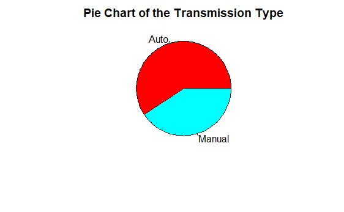

```r
ttype = table(mtcars$am) # To get the levels of the variable
ttype_lbls = c("Auto", "Manual")
pie(ttype, labels = ttype_lbls, col = rainbow(length(ttype_lbls)), main = "Pie Chart of the Transmission Type")
```

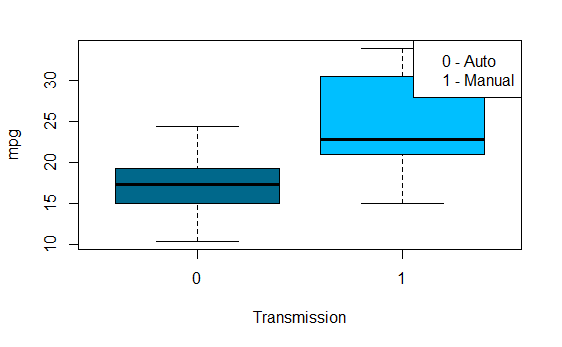

```r
boxplot(mpg~am, data = mtcars, xlab = "Transmission", ylab = "mpg", col = c("deepskyblue4", "deepskyblue"))
legend("topright", legend = c("0 - Auto", "1 - Manual"))
```

##### (d) In the R tutorial we did in the class, we talked about accessing a certain column of a dataframe. Use the R functions; mean() and sd() to find the mean and the standard deviation of the variable mpg.

```r
mean(mtcars$mpg) # mean of variable mpg
```

```
[1] 20.09062
```

```r
sd(mtcars$mpg) # standard deviation of variable mpg
```

```
[1] 6.026948
```

#### (2). Records maintained by the office on budget in a certain state indicate that amount of time elapsed between the submission of travel vouchers and the final reimbursement of funds has approximately a normal distribution with a mean of 39 days and a standard deviation of 6 days. If you had a travel voucher submitted more than 55 days ago, what might you conclude?

we need to find
$$P(X>55)$$
, to calculate that we use
$$1-P(X<55)$$

```r
1 - pnorm(55, mean = 39, sd = 6)
```

```
[1] 0.003830381
```

With this really low probability, I would conclude that I won’t receive any reimbursement.